# BITS ID: 2026AJ05102

# NAME: BIHAG KASHIKAR

# Assignment 2 - Optimization Using Python

# QUESTION 1 - Exact Line Search for a Quadratic Objective

Sections below answer Question 1(a)–(c).

```python
import numpy as np
import matplotlib.pyplot as plt
from matplotlib.lines import Line2D
from matplotlib.patches import Arc

np.set_printoptions(precision=10, suppress=True)
```

## (a) Implement exact line search

The gradient is $\nabla J(w_t)=Aw_t+b$. The negative-gradient direction and exact step size are

$$g_t=-(Aw_t+b), \qquad \alpha_t=\frac{g_t^Tg_t}{g_t^TAg_t},$$

followed by $w_{t+1}=w_t+\alpha_tg_t$. Stop when $\|Aw_t+b\|_2<10^{-10}$ or when the maximum number of steps is reached. The returned list contains independent copies of the initial point and each generated point.

```python
def exact_line_search_quadratic(A, b, w0, num_steps):
    """Minimize 0.5 * w.T @ A @ w + b.T @ w by exact line search."""
    A = np.asarray(A, dtype=float)
    b = np.asarray(b, dtype=float)
    w = np.asarray(w0, dtype=float).copy()

    if A.ndim != 2 or A.shape[0] != A.shape[1] or A.shape[0] == 0:
        raise ValueError("A must be a non-empty square matrix.")
    if b.shape != (A.shape[0],) or w.shape != (A.shape[0],):
        raise ValueError("b and w0 must be vectors with length matching A.")
    if not np.all(np.isfinite(A)) or not np.all(np.isfinite(b)) or not np.all(np.isfinite(w)):
        raise ValueError("A, b, and w0 must contain only finite values.")
    if not np.allclose(A, A.T):
        raise ValueError("A must be symmetric.")
    if isinstance(num_steps, (bool, np.bool_)) or not isinstance(num_steps, (int, np.integer)) or num_steps < 0:
        raise ValueError("num_steps must be a non-negative integer.")

    try:
        np.linalg.cholesky(A)
    except np.linalg.LinAlgError as exc:
        raise ValueError("A must be positive definite.") from exc

    iterates = [w.copy()]
    tolerance = 1e-10

    for _ in range(num_steps):
        gradient = A @ w + b
        if np.linalg.norm(gradient, ord=2) < tolerance:
            break

        direction = -gradient
        denominator = float(direction @ A @ direction)
        if not np.isfinite(denominator) or denominator <= 0.0:
            raise FloatingPointError(
                "The exact line-search denominator is not positive and finite."
            )

        step_size = float(direction @ direction) / denominator
        next_w = w + step_size * direction
        if not np.all(np.isfinite(next_w)):
            raise FloatingPointError("The update produced a non-finite iterate.")

        w = next_w
        iterates.append(w.copy())

    return iterates
```

## (b) Run the specified example

The assignment data are $A=\begin{bmatrix}2&0\\0&8\end{bmatrix}$, $b=[0,0]^T$, and $w_0=[2,1]^T$, giving $J(w_1,w_2)=w_1^2+4w_2^2$. The minimizer is $w^*=(0,0)$.

```python
A = np.array([[2.0, 0.0], [0.0, 8.0]])
b = np.array([0.0, 0.0])
w0 = np.array([2.0, 1.0])
num_steps = 10

def objective(w):
    return 0.5 * w @ A @ w + b @ w

iterates = exact_line_search_quadratic(A, b, w0, num_steps)
print(f"Returned {len(iterates)} points (including the initial point):")
for t, w_t in enumerate(iterates):
    print(f"w_{t} = {w_t}")

print("\nObjective values:")
for t, w_t in enumerate(iterates):
    print(f"J(w_{t}) = {objective(w_t):.12g}")
```

```
Returned 11 points (including the initial point):
w_0 = [2. 1.]
w_1 = [ 1.4117647059 -0.1764705882]
w_2 = [0.5294117647 0.2647058824]
w_3 = [ 0.3737024221 -0.0467128028]
w_4 = [0.1401384083 0.0700692042]
w_5 = [ 0.0989212294 -0.0123651537]
w_6 = [0.037095461  0.0185477305]
w_7 = [ 0.0261850313 -0.0032731289]
w_8 = [0.0098193867 0.0049096934]
w_9 = [ 0.0069313318 -0.0008664165]
w_10 = [0.0025992494 0.0012996247]

Objective values:
J(w_0) = 8
J(w_1) = 2.11764705882
J(w_2) = 0.560553633218
J(w_3) = 0.148381844087
J(w_4) = 0.0392775469642
J(w_5) = 0.0103969977258
J(w_6) = 0.00275214645684
J(w_7) = 0.000728509356221
J(w_8) = 0.000192840711941
J(w_9) = 5.10460708079e-05
J(w_10) = 1.35121952139e-05
```

### Consecutive-gradient dot products

For exact line search, $g_t^Tg_{t+1}$ should be zero in exact arithmetic. The check below uses the absolute tolerance $10^{-10}$ and only evaluates indices for which both gradients are available.

```python
gradients = [-(A @ w_t + b) for w_t in iterates]
dot_tolerance = 1e-10

print(f"Approximate-zero criterion: |g_t.T @ g_(t+1)| <= {dot_tolerance:g}\n")
for t in range(min(5, len(gradients) - 1)):
    dot_product = float(gradients[t] @ gradients[t + 1])
    approximately_zero = abs(dot_product) <= dot_tolerance
    print(
        f"t={t}: g_{t}.T @ g_{t + 1} = {dot_product:.12g}; "
        f"approximately zero: {approximately_zero}"
    )
```

```
Approximate-zero criterion: |g_t.T @ g_(t+1)| <= 1e-10

t=0: g_0.T @ g_1 = -3.5527136788e-15; approximately zero: True
t=1: g_1.T @ g_2 = 0; approximately zero: True
t=2: g_2.T @ g_3 = 1.44328993201e-15; approximately zero: True
t=3: g_3.T @ g_4 = 1.11022302463e-16; approximately zero: True
t=4: g_4.T @ g_5 = -1.38777878078e-17; approximately zero: True
```

## (c) Plot the optimization path

The contour plot shows $J(w_1,w_2)=w_1^2+4w_2^2$. Each consecutive pair of iterates is joined by a line segment. At each intermediate iterate, a small arc marks the angle between the rays toward the previous and next iterates; the exact-line-search path is expected to turn by approximately $90^\circ$ there. These are path-turn angles, not contour tangencies.

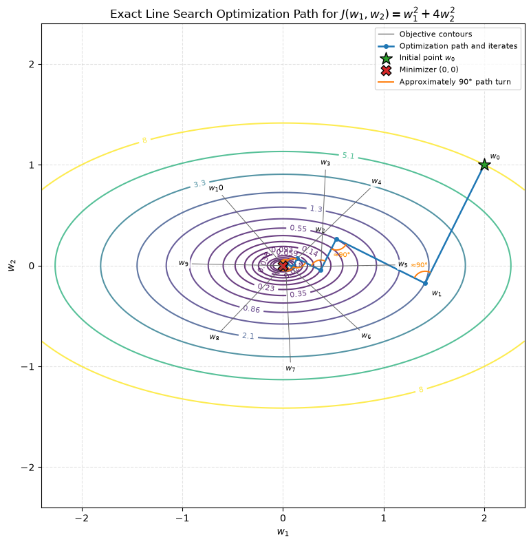

```python
path = np.asarray(iterates)
grid_extent = 2.4
grid_values = np.linspace(-grid_extent, grid_extent, 300)
W1, W2 = np.meshgrid(grid_values, grid_values)
J_grid = W1**2 + 4.0 * W2**2
positive_levels = np.geomspace(0.01, 8.0, 16)

fig, ax = plt.subplots(figsize=(9, 8))
contours = ax.contour(W1, W2, J_grid, levels=positive_levels, cmap="viridis", alpha=0.8)
ax.clabel(contours, inline=True, fontsize=8, fmt="%.2g")

path_line, = ax.plot(
    path[:, 0], path[:, 1], "-o", color="tab:blue", linewidth=1.8,
    markersize=4, label="Optimization path and iterates", zorder=3
)
ax.scatter(*path[0], marker="*", s=180, color="tab:green", edgecolor="black",
           label="Initial point $w_0$", zorder=5)
ax.scatter(0.0, 0.0, marker="X", s=110, color="tab:red", edgecolor="black",
           label="Minimizer $(0,0)$", zorder=6)

label_offsets = [(6, 6), (7, -13), (-22, 7), (0, 110), (78, 78),
                 (110, 0), (78, -78), (0, -110), (-78, -78),
                 (-110, 0), (-78, 78)]
for t, point in enumerate(path):
    annotation_options = {}
    if t >= 3:
        annotation_options = {
            "arrowprops": {"arrowstyle": "-", "color": "0.4", "linewidth": 0.7},
            "bbox": {"boxstyle": "round,pad=0.15", "facecolor": "white",
                     "edgecolor": "none", "alpha": 0.9},
        }
    ax.annotate(f"$w_{t}$", point, xytext=label_offsets[t],
                textcoords="offset points", fontsize=8, zorder=7,
                **annotation_options)

angle_label_added = False
for t in range(1, len(path) - 1):
    ray_to_previous = path[t - 1] - path[t]
    ray_to_next = path[t + 1] - path[t]
    angle_previous = np.degrees(np.arctan2(ray_to_previous[1], ray_to_previous[0]))
    angle_next = np.degrees(np.arctan2(ray_to_next[1], ray_to_next[0]))
    angle_span = (angle_next - angle_previous) % 360.0
    if angle_span > 180.0:
        angle_previous, angle_next = angle_next, angle_previous
        angle_span = 360.0 - angle_span

    radius = 0.12 - 0.075 * (t - 1) / max(1, len(path) - 3)
    arc = Arc(path[t], 2 * radius, 2 * radius, angle=0,
              theta1=angle_previous, theta2=angle_previous + angle_span,
              color="tab:orange", linewidth=1.4, zorder=4)
    ax.add_patch(arc)

    if t <= 2:
        middle_angle = np.radians(angle_previous + angle_span / 2.0)
        label_point = path[t] + 1.55 * radius * np.array(
            [np.cos(middle_angle), np.sin(middle_angle)]
        )
        ax.text(*label_point, "≈90°", color="darkorange", fontsize=7,
                ha="center", va="center", zorder=8)

    if not angle_label_added:
        angle_handle = Line2D([], [], color="tab:orange", linewidth=1.4,
                              label="Approximately 90° path turn")
        angle_label_added = True

contour_handle = Line2D([], [], color="0.45", linewidth=1.0,
                        label="Objective contours")
handles, labels = ax.get_legend_handles_labels()
handles.insert(0, contour_handle)
labels.insert(0, "Objective contours")
if angle_label_added:
    handles.append(angle_handle)
    labels.append("Approximately 90° path turn")
ax.legend(handles=handles, labels=labels, loc="upper right", fontsize=8)
ax.set_xlabel("$w_1$")
ax.set_ylabel("$w_2$")
ax.set_title("Exact Line Search Optimization Path for $J(w_1,w_2)=w_1^2+4w_2^2$")
ax.set_xlim(-grid_extent, grid_extent)
ax.set_ylim(-grid_extent, grid_extent)
ax.set_aspect("equal", adjustable="box")
ax.grid(True, linestyle="--", alpha=0.35)
plt.tight_layout()
plt.show()
```

# QUESTION 2 - Gradient Descent, Momentum and RMSProp

Sections below answer Question 2(a)–(b).

```python
import numpy as np
import matplotlib.pyplot as plt
from matplotlib.lines import Line2D

np.set_printoptions(precision=10, suppress=True)
```

## (a) Implement the optimizers

Each routine stores a copy of the initial point and a copy after each update, so the returned list contains `num_iters + 1` points. Gradients are obtained only through the supplied `grad_fn`.

- **Vanilla GD:** $w_{t+1}=w_t-\alpha\nabla J(w_t)$.
- **Momentum:** $v_0=0$, $v_{t+1}=\beta v_t+\nabla J(w_t)$, then $w_{t+1}=w_t-\alpha v_{t+1}$.
- **RMSProp:** $s_0=0$, $s_{t+1}=\rho s_t+(1-\rho)(\nabla J(w_t)\odot\nabla J(w_t))$, then $w_{t+1}=w_t-\alpha\nabla J(w_t)/(\sqrt{s_{t+1}}+\epsilon)$. RMSProp's square, square root, and division are element-wise.

```python
def _prepare_optimizer_inputs(grad_fn, w0, num_iters):
    if not callable(grad_fn):
        raise TypeError("grad_fn must be callable.")
    w = np.asarray(w0, dtype=float)
    if w.ndim != 1 or w.size == 0:
        raise ValueError("w0 must be a non-empty one-dimensional array.")
    if not np.all(np.isfinite(w)):
        raise ValueError("w0 must contain only finite values.")
    if (isinstance(num_iters, (bool, np.bool_))
            or not isinstance(num_iters, (int, np.integer))
            or num_iters < 0):
        raise ValueError("num_iters must be a non-negative integer.")
    return w.copy()


def _gradient(grad_fn, w):
    gradient = np.asarray(grad_fn(w.copy()), dtype=float)
    if gradient.shape != w.shape:
        raise ValueError("grad_fn must return a gradient with the same shape as w.")
    if not np.all(np.isfinite(gradient)):
        raise FloatingPointError("grad_fn returned a non-finite gradient.")
    return gradient


def _validate_learning_rate(alpha):
    if not np.isfinite(alpha) or alpha <= 0:
        raise ValueError("alpha must be positive and finite.")


def vanilla_gd(grad_fn, w0, alpha, num_iters):
    """Run vanilla gradient descent and return the initial point and all updates."""
    w = _prepare_optimizer_inputs(grad_fn, w0, num_iters)
    _validate_learning_rate(alpha)
    iterates = [w.copy()]

    for _ in range(num_iters):
        gradient = _gradient(grad_fn, w)
        w = w - alpha * gradient
        if not np.all(np.isfinite(w)):
            raise FloatingPointError("The vanilla GD update produced a non-finite iterate.")
        iterates.append(w.copy())

    return iterates


def momentum_gd(grad_fn, w0, alpha, beta, num_iters):
    """Run momentum gradient descent and return the initial point and all updates."""
    w = _prepare_optimizer_inputs(grad_fn, w0, num_iters)
    _validate_learning_rate(alpha)
    if not np.isfinite(beta) or not 0.0 <= beta < 1.0:
        raise ValueError("beta must be finite and satisfy 0 <= beta < 1.")

    velocity = np.zeros_like(w)
    iterates = [w.copy()]

    for _ in range(num_iters):
        gradient = _gradient(grad_fn, w)
        velocity = beta * velocity + gradient
        w = w - alpha * velocity
        if not np.all(np.isfinite(w)):
            raise FloatingPointError("The momentum update produced a non-finite iterate.")
        iterates.append(w.copy())

    return iterates


def rmsprop_gd(grad_fn, w0, alpha, rho, epsilon, num_iters):
    """Run RMSProp and return the initial point and all updates."""
    w = _prepare_optimizer_inputs(grad_fn, w0, num_iters)
    _validate_learning_rate(alpha)
    if not np.isfinite(rho) or not 0.0 <= rho < 1.0:
        raise ValueError("rho must be finite and satisfy 0 <= rho < 1.")
    if not np.isfinite(epsilon) or epsilon <= 0.0:
        raise ValueError("epsilon must be positive and finite.")

    squared_gradient_average = np.zeros_like(w)
    iterates = [w.copy()]

    for _ in range(num_iters):
        gradient = _gradient(grad_fn, w)
        squared_gradient_average = (
            rho * squared_gradient_average + (1.0 - rho) * (gradient * gradient)
        )
        w = w - alpha * gradient / (np.sqrt(squared_gradient_average) + epsilon)
        if not np.all(np.isfinite(w)):
            raise FloatingPointError("The RMSProp update produced a non-finite iterate.")
        iterates.append(w.copy())

    return iterates
```

## (b) Run and compare the optimizers

For all three methods use $w_0=[3,1]^T$, $\alpha=0.05$, and 50 iterations. I have selected parameters are $\beta=0.9$ for Momentum and $\rho=0.9$, $\epsilon=10^{-8}$ for RMSProp.

```python
def grad_fn(w):
    """Gradient of J(w1, w2) = w1^2 + 10*w2^2."""
    return np.array([2.0 * w[0], 20.0 * w[1]])


def objective(w):
    return w[0] ** 2 + 10.0 * w[1] ** 2


w0 = np.array([3.0, 1.0])
alpha = 0.05
num_iters = 50
beta = 0.9
rho = 0.9
epsilon = 1e-8

vanilla_iterates = vanilla_gd(grad_fn, w0, alpha, num_iters)
momentum_iterates = momentum_gd(grad_fn, w0, alpha, beta, num_iters)
rmsprop_iterates = rmsprop_gd(grad_fn, w0, alpha, rho, epsilon, num_iters)

paths = {
    "Vanilla GD": np.asarray(vanilla_iterates),
    "Momentum": np.asarray(momentum_iterates),
    "RMSProp": np.asarray(rmsprop_iterates),
}
losses = {
    name: np.array([objective(point) for point in path])
    for name, path in paths.items()
}

for name, path in paths.items():
    assert len(path) == num_iters + 1
    print(f"{name}: {len(path)} points, including w_0")
    print(f"  initial point: {path[0]}")
    print(f"  final point:   {path[-1]}")
    print(f"  initial loss:  {losses[name][0]:.12g}")
    print(f"  final loss:    {losses[name][-1]:.12g}")
```

```
Vanilla GD: 51 points, including w_0
  initial point: [3. 1.]
  final point:   [0.0154613256 0.          ]
  initial loss:  19
  final loss:    0.000239052589988
Momentum: 51 points, including w_0
  initial point: [3. 1.]
  final point:   [-0.2000407167 -0.0496523522]
  initial loss:  19
  final loss:    0.0646698491083
RMSProp: 51 points, including w_0
  initial point: [3. 1.]
  final point:   [0.5690895958 0.0000000019]
  initial loss:  19
  final loss:    0.323862968054
```

### Loss versus iteration

The vertical axis is logarithmic. If a computed loss is zero, the display-only values are floored at the smallest positive normal floating-point number so the plot does not take $\log(0)$. This floor is used only for plotting; the `losses` arrays retain the actual objective values.

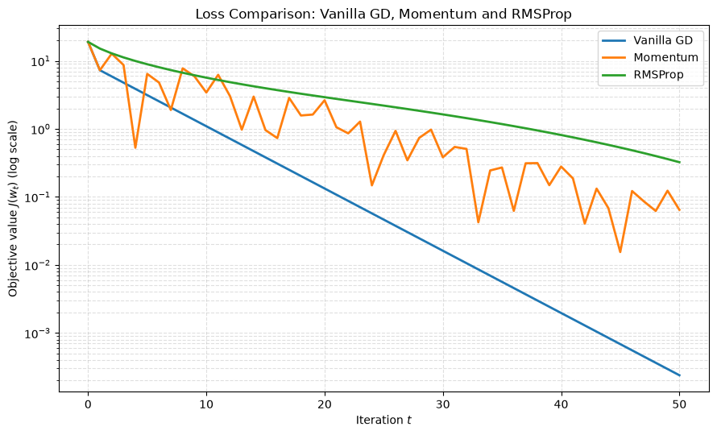

```
Vanilla GD: exact numerical zeros at iterations []
Momentum: exact numerical zeros at iterations []
RMSProp: exact numerical zeros at iterations []
```

```python
iterations = np.arange(num_iters + 1)
display_floor = np.finfo(float).tiny
colors = {"Vanilla GD": "tab:blue", "Momentum": "tab:orange", "RMSProp": "tab:green"}

fig, ax = plt.subplots(figsize=(9, 5.5))
for name, values in losses.items():
    plotted_values = np.maximum(values, display_floor)
    ax.semilogy(iterations, plotted_values, linewidth=2, color=colors[name], label=name)

ax.set_xlabel("Iteration $t$")
ax.set_ylabel("Objective value $J(w_t)$ (log scale)")
ax.set_title("Loss Comparison: Vanilla GD, Momentum and RMSProp")
ax.legend()
ax.grid(True, which="both", linestyle="--", alpha=0.4)
plt.tight_layout()
plt.show()

for name, values in losses.items():
    zero_iterations = np.flatnonzero(values == 0.0)
    print(f"{name}: exact numerical zeros at iterations {zero_iterations.tolist()}")
```

### Optimization paths over common contours

Each panel shows the same objective contours with matching contour levels and identical axis limits, so the trajectories can be compared directly. The star marks the common initial point.

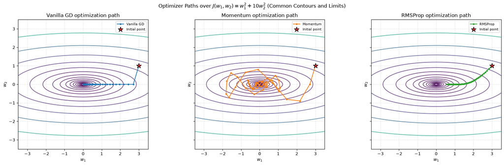

```
Shared axis limits: (-3.5, 3.5)
Shared contour levels: [  0.01    0.017   0.031   0.054   0.094   0.164   0.287   0.502   0.878
   1.535   2.686   4.699   8.222  14.384  25.165  44.025  77.022 134.75 ]
```

```python
all_points = np.concatenate(list(paths.values()), axis=0)
axis_extent = max(3.5, 1.08 * float(np.max(np.abs(all_points))))
axis_limits = (-axis_extent, axis_extent)

coordinate_values = np.linspace(axis_limits[0], axis_limits[1], 350)
W1, W2 = np.meshgrid(coordinate_values, coordinate_values)
J_grid = W1**2 + 10.0 * W2**2
contour_levels = np.geomspace(0.01, float(np.max(J_grid)), 18)

fig, axes = plt.subplots(1, 3, figsize=(18, 5.5), sharex=True, sharey=True)
for ax, (name, path) in zip(axes, paths.items()):
    ax.contour(W1, W2, J_grid, levels=contour_levels, cmap="viridis", alpha=0.7)
    ax.plot(path[:, 0], path[:, 1], "-o", color=colors[name], linewidth=1.5,
            markersize=3, label=name, zorder=3)
    ax.scatter(*path[0], marker="*", s=150, color="tab:red", edgecolor="black",
               label="Initial point", zorder=4)
    ax.set_title(f"{name} optimization path")
    ax.set_xlabel("$w_1$")
    ax.set_ylabel("$w_2$")
    ax.set_xlim(axis_limits)
    ax.set_ylim(axis_limits)
    ax.set_aspect("equal", adjustable="box")
    ax.grid(True, linestyle="--", alpha=0.35)
    ax.legend(loc="upper right", fontsize=8)
fig.suptitle("Optimizer Paths over $J(w_1,w_2)=w_1^2+10w_2^2$ (Common Contours and Limits)")
plt.tight_layout()
plt.show()

print(f"Shared axis limits: {axis_limits}")
print(f"Shared contour levels: {np.array2string(contour_levels, precision=3)}")
```